# Optimizing antimicrobial therapy in patients with liver and kidney failure

A PK/PD perspective, centred on β-lactams

Russell E. Lewis, Pharm.D., FCCP

2026-11-18

# Optimizing antimicrobial therapy in patients with liver and kidney dysfunction

**Russell E. Lewis, Pharm.D., FCCP**  
Associate Professor of Infectious Diseases

russelledward.lewis@unipd.it

https://lewis-id-lab.github.io

## This talk makes three assertions about antimicrobial dosing in patients with impaired kidney or liver impairment

Dose for the infection first

Better to measure than estimate

Protein binding is not constant

# 1 · Dose for the infection first

## Hypothetical patient

- 58-year-old, alcohol-related cirrhosis (Child-Pugh B, albumin 2.2 g/dL)
- Presents with septic shock from secondary peritonitis
- Creatinine 2.1 mg/dL (baseline 0.8), no urine for 6 h.
- **Meropenem is ordered; the renal-dosing table in package labeling proposes 1 g q12h.**

## Dose adjustment in the first 24-48 hours: A good idea?

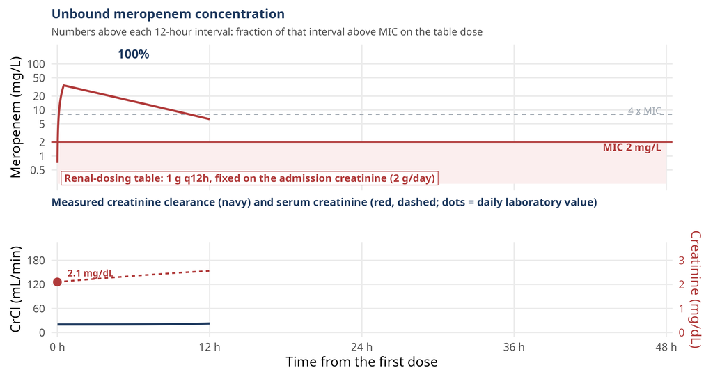

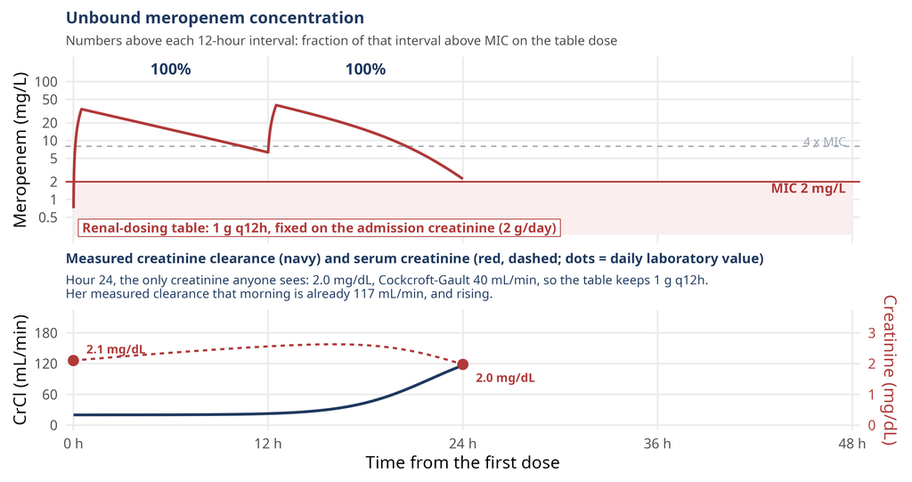

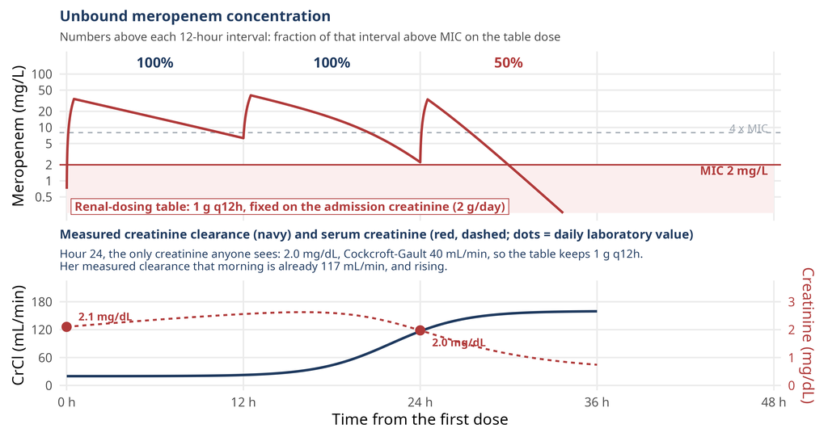

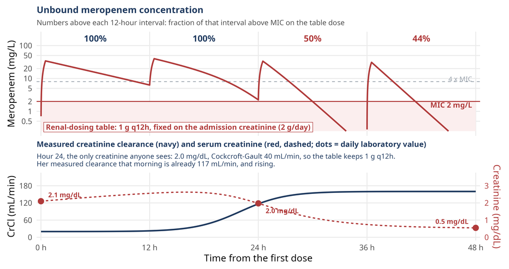

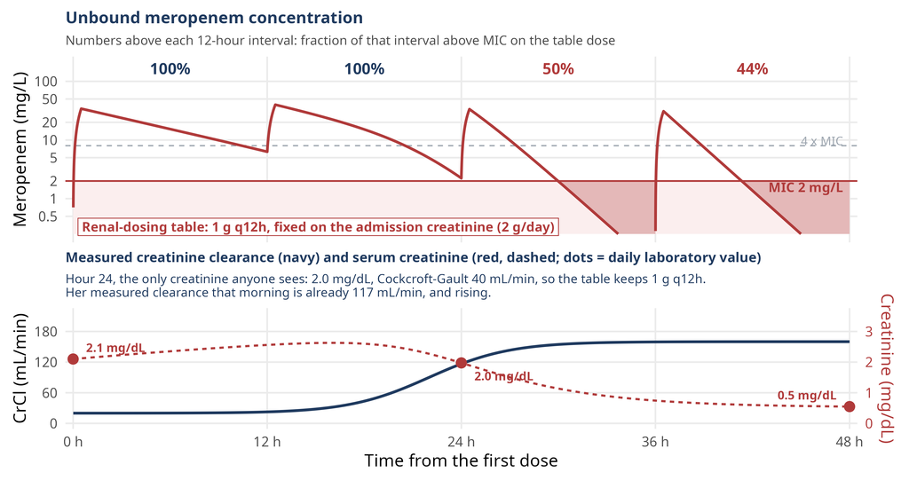

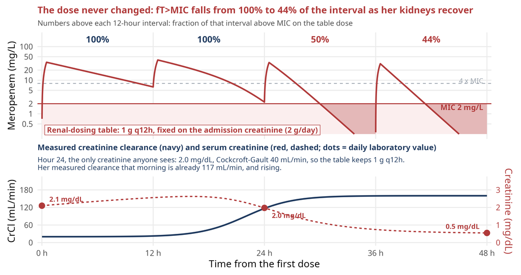

Mechanistic simulation of the patient on the previous slide, not data. Meropenem model V 28.2 L, typical CL 8.35 L/h: (Bastida et al., 2020). The recovery trajectory and the creatinine pool are assumed; timing of resolution (Crass et al., 2019), ARC prevalence (Hefny et al., 2022; Udy et al., 2014). MIC 2 mg/L (EUCAST breakpoint); meropenem is ~2% bound, so unbound = total

## More than half of the acute kidney injury present when infection is diagnosed resolves within 48 hours

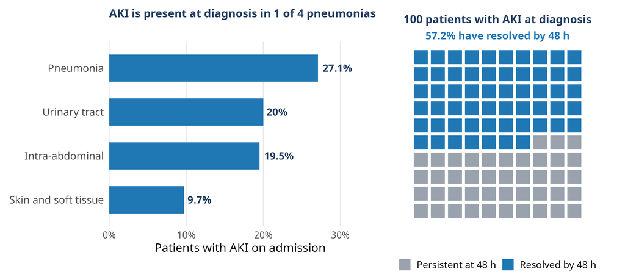

Admission AKI and 48-h resolution: (Crass et al., 2019). AKI in 57.3% of ICU patients: (Hoste et al., 2015)

## Reducing β-lactam doses for kidney injury in the first 24–48 hours is associated with worse outcomes

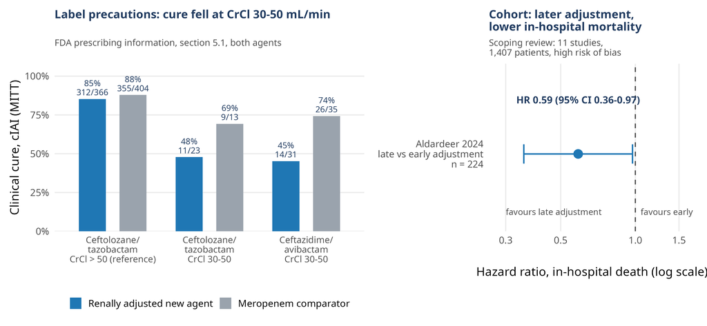

Label precautions (section 5.1): (US Food and Drug Administration, 2022, 2025); rationale: (Crass et al., 2019; Kullar et al., 2017). Scoping review: (Horstink et al., 2025). Cohort: (Aldardeer et al., 2024)

## Prolonged infusion after a loading dose lowers mortality in pooled trials; the two largest single trials were neutral

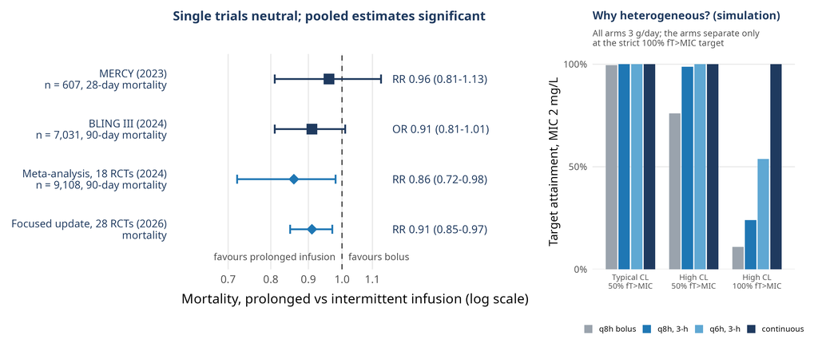

Trials and syntheses: (Abdul-Aziz et al., 2024; Dulhunty et al., 2024; Hong et al., 2026; Monti et al., 2023). Guideline: (Prescott et al., 2026). Inset: mechanistic simulation, structural model (Bastida et al., 2020), variability assumed

## In kidney failure, overexposure is measurable harm: cefepime neurotoxicity tracks the trough concentration

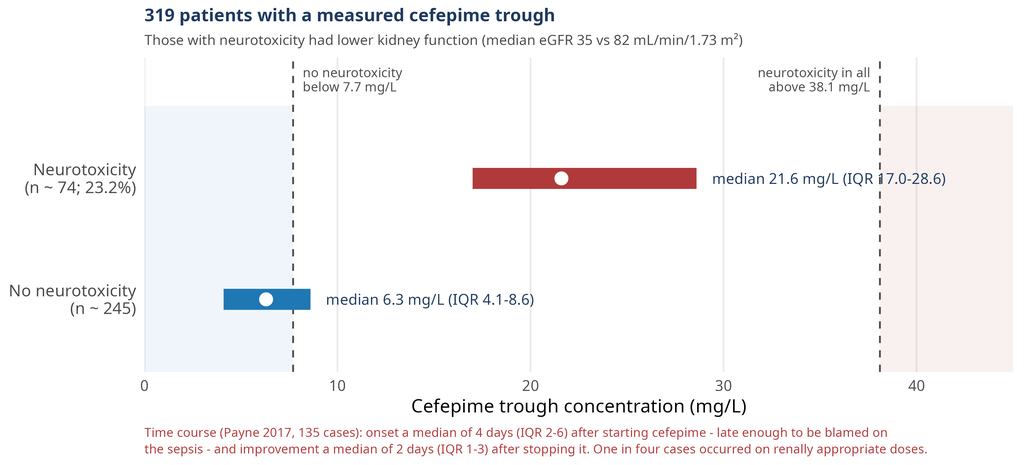

Thresholds: (Boschung-Pasquier et al., 2020; Imani et al., 2017). Time course: (Payne et al., 2017). Randomised comparison: (Qian et al., 2023)

# 2 · Better to measure than estimate

## Creatinine-based equations get the average right and the individual patient wrong in critical illness

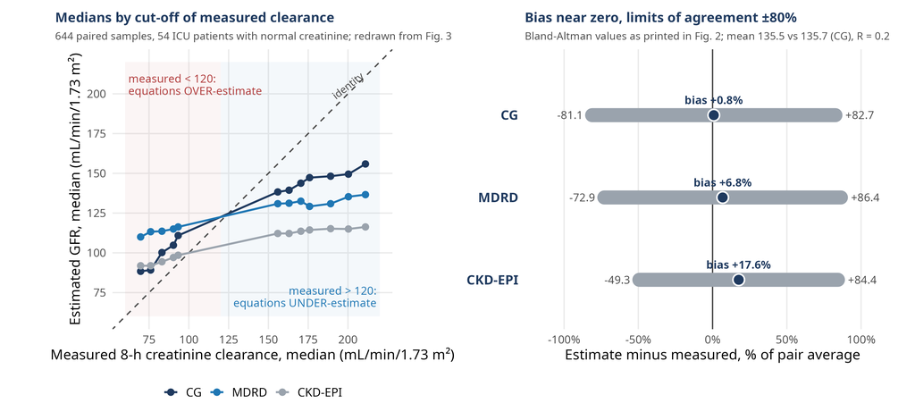

Redrawn from (Baptista et al., 2014): Fig. 3 medians digitised from the published chart (about 0.3 mL/min resolution), Fig. 2 values as printed. Inulin reference: (Carlier et al., 2015). Cystatin C: (Barreto et al., 2023; Hanna et al., 2023)

## In cirrhosis, every GFR equation overestimates once the true value falls below 60 — by 10 to 22 mL/min

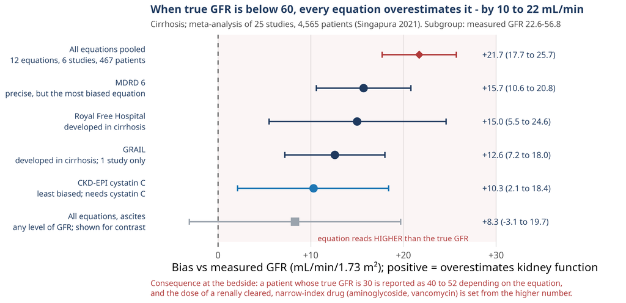

Meta-analysis: (Singapura et al., 2021) (25 studies, 4,565 patients; the <60 subset is 6 studies, 467 patients). Consensus definitions of HRS-AKI: (Nadim et al., 2024)

## Four in ten ICU patients have augmented renal clearance, which predicts sub-MIC β-lactam troughs

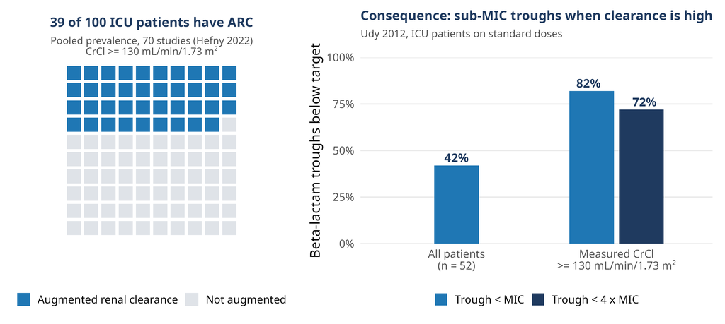

Prevalence: (Hefny et al., 2022; Udy et al., 2014). Exposure: (Abdulla et al., 2020; Udy et al., 2012; Wong et al., 2018). Outcome with high-dose continuous infusion: (Carrié et al., 2018)

## During RRT, urine output and RRT intensity set the dose

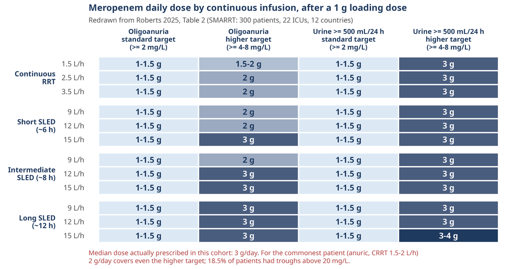

Redrawn from (Roberts et al., 2025), Table 2 (open access, CC BY): doses transcribed, merged cells expanded to the intensities they cover. Observational PK data: (Roberts et al., 2021). Vancomycin equivalent: (Ulldemolins et al., 2026)

## TDM and model-informed precision dosing (MIPD)

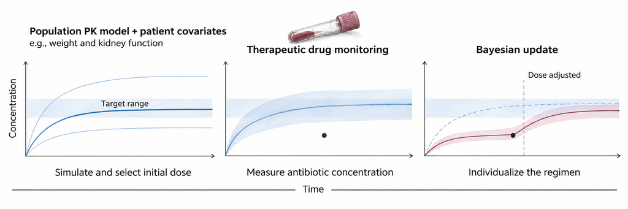

## TDM-guided dosing raised target attainment in two of three randomised trials, but did not improve clinical outcomes

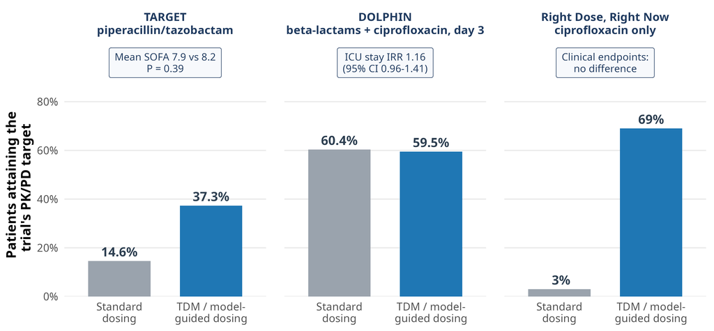

Published trial percentages: (Ewoldt et al., 2022; Hagel et al., 2022; Roggeveen et al., 2022). Meta-analysis: (Pai Mangalore et al., 2022). Guideline: (Prescott et al., 2026)

## Few antimicrobials carry a hepatic dose adjustment; for β-lactams, kidney function and albumin matter more

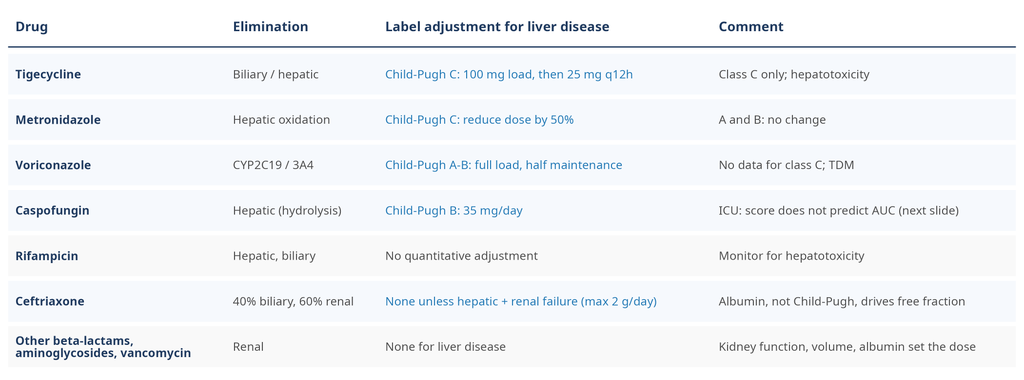

Reviews: (Halilovic and Heintz, 2014; Verbeeck, 2008). Systematic review in cirrhosis: (Comce et al., 2024). Label cells: current US prescribing information of each drug (verify before presenting)

## Liver failure enlarges the distribution volume, so first-day β-lactam exposure falls short

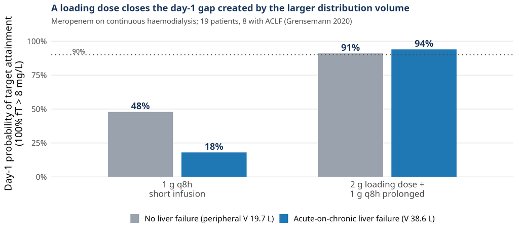

ACLF on CVVHD: (Grensemann et al., 2020). Decompensated cirrhosis: (Bastida et al., 2020). Outcome cohort: (Bartoletti et al., 2019)

## Do not reduce caspofungin for a Child-Pugh B score driven by hypoalbuminaemia, not by cirrhosis

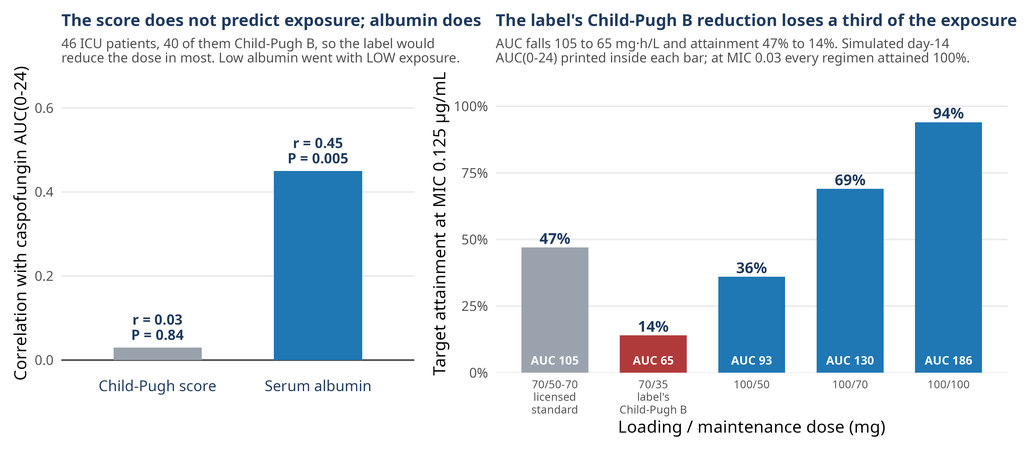

ICU cohort: (Kurland et al., 2019). Population PK and simulated regimens: (Martial et al., 2016). Both authors’ explicit recommendation, not our inference

# 3 · Protein binding is not a constant

## The unbound fraction is not a constant: in ICU patients it spans up to tenfold around the textbook value

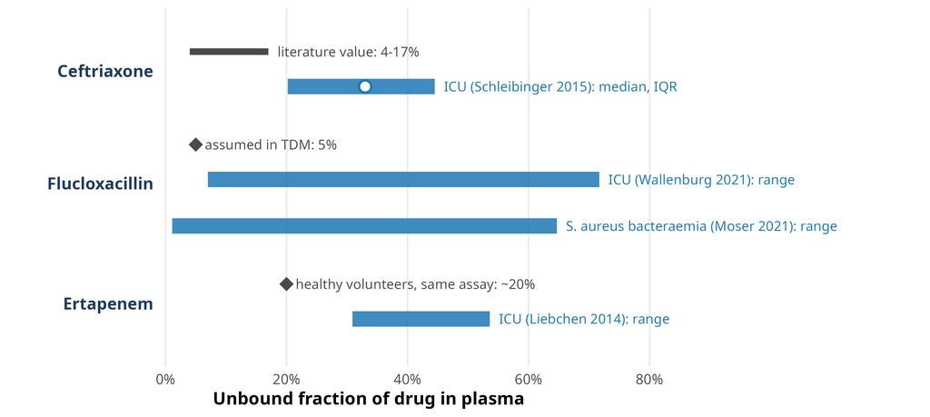

Published summary statistics. Ceftriaxone: (Schleibinger et al., 2015; Wong et al., 2013). Flucloxacillin: (Moser et al., 2021; Wallenburg et al., 2021). Ertapenem: (Liebchen et al., 2014)

## For the same measured total concentration, a fixed unbound fraction can misclassify target attainment

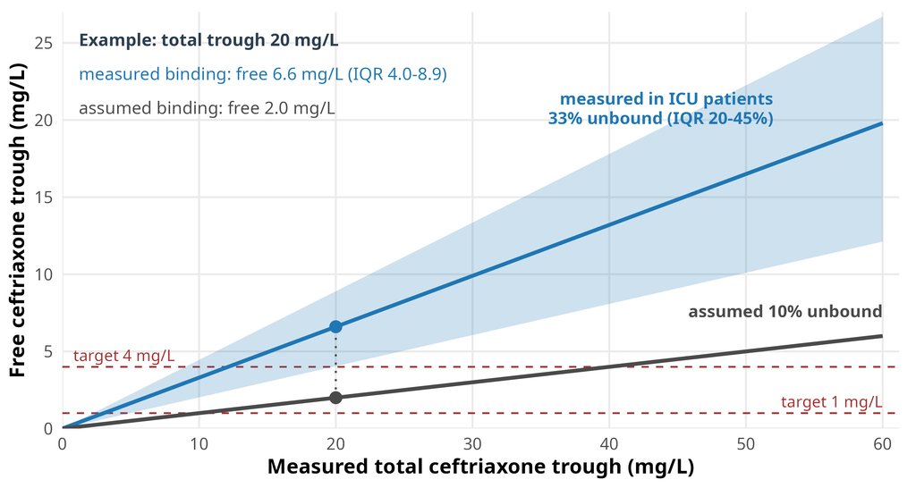

Arithmetic on published values: (Gijsen et al., 2021; Schleibinger et al., 2015). Bias in population target-attainment estimates: (Toutain et al., 2023). Band assumes concentration-independent binding; ceftriaxone binding is saturable (Heffernan et al., 2022)

## Hypoalbuminaemia linked to failure of ertapenem and ceftriaxone

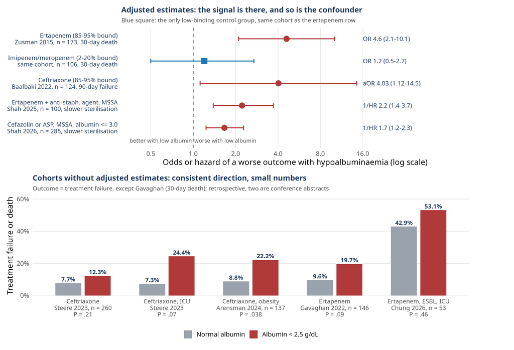

Adjusted estimates: (Baalbaki et al., 2022; Shah et al., 2025, 2026; Zusman et al., 2015). Crude cohorts: (Arensman Hannan et al., 2024; Chung et al., 2026; Gavaghan et al., 2022; Steere et al., 2023); drug comparison (VanDorf et al., 2024). Review: (Acbo et al., 2025). Guidance: (Tamma et al., 2024)

## Low albumin empties the trough and leaves the average: shorten the interval or raise the dose

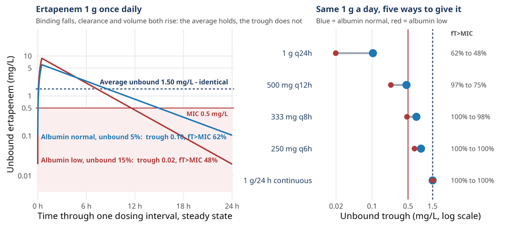

Mechanistic simulation, not data. Structural premise — unbound intrinsic clearance is unchanged by binding — from (Benet and Hoener, 2002; Gandia et al., 2023); ICU unbound fractions (T’jollyn et al., 2018). Clinical corollaries: 2 g ceftriaxone in hypoalbuminaemia (Ackerman et al., 2020); meropenem preferred over ertapenem (Tamma et al., 2024)

## An albumin correction of the phenytoin type fails for β-lactams, and performs poorly even for phenytoin in the ICU

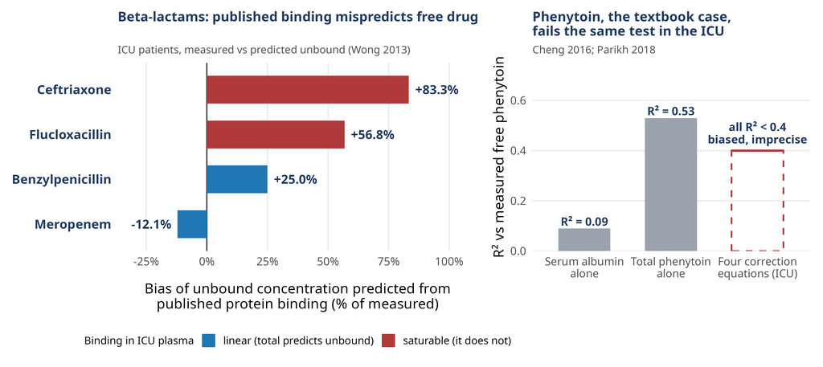

β-lactams: (Wong et al., 2013); a population-specific saturable-binding model does predict free ceftriaxone: (Gijsen et al., 2021). Phenytoin: (Cheng et al., 2016; Kiang and Ensom, 2016; Parikh and MacLaren, 2018); mechanistic non-linear model: (Heine et al., 2019)

## In the first 48 hours dose for the infection; after 48 hours dose for the measured organ function

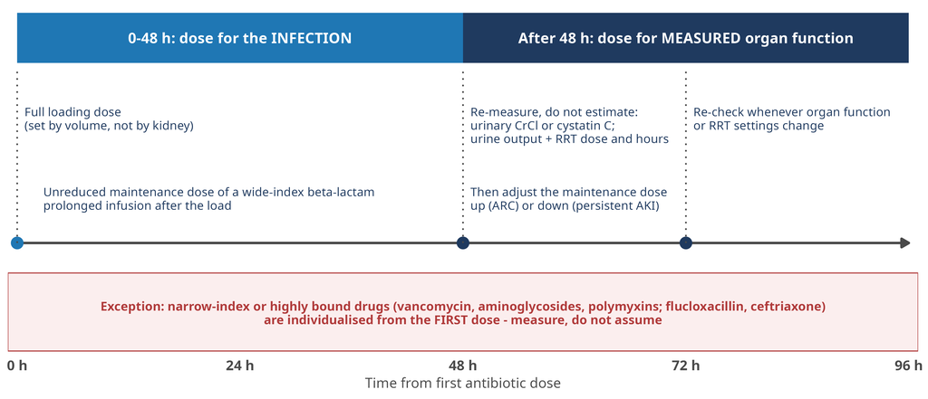

## Three claims to take home

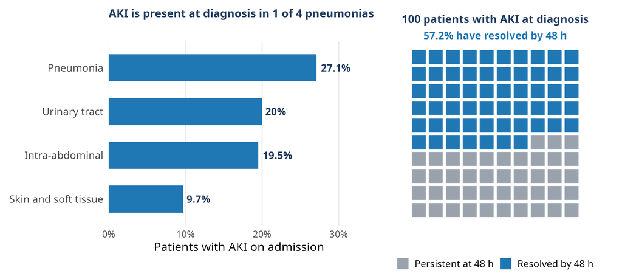

**1 · Dose for the infection first.** Full loading dose, unreduced wide-index β-lactam, prolonged infusion; re-measure at 48 h.

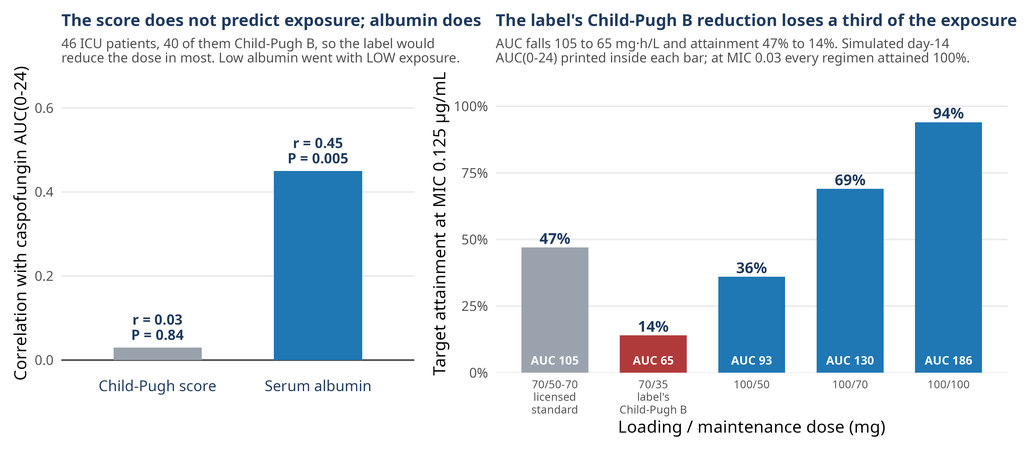

**2 · Measure, do not estimate.** Urinary CrCl or cystatin C, urine output and RRT dose; not Cockcroft-Gault, Child-Pugh or the label table.

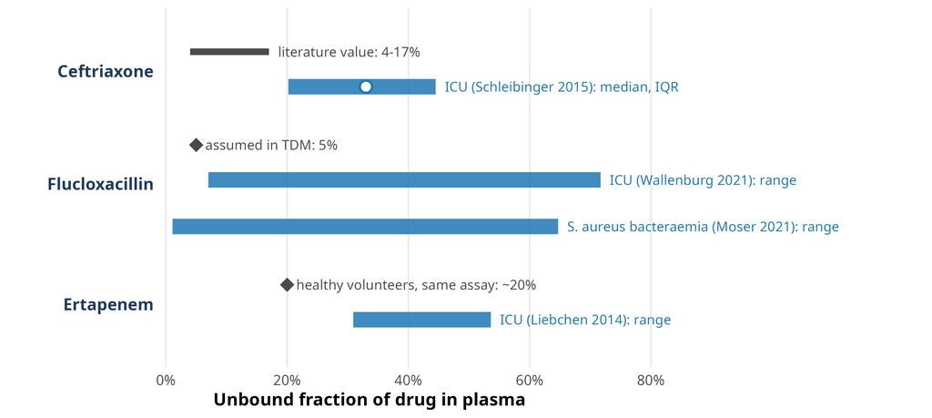

**3 · Binding is not a constant.** For highly bound drugs, measure unbound drug or use a saturable-binding model; no fixed fraction, no albumin formula.

## Backup: extended and continuous infusion are equivalent at 50% fT>MIC; they separate only under stricter targets

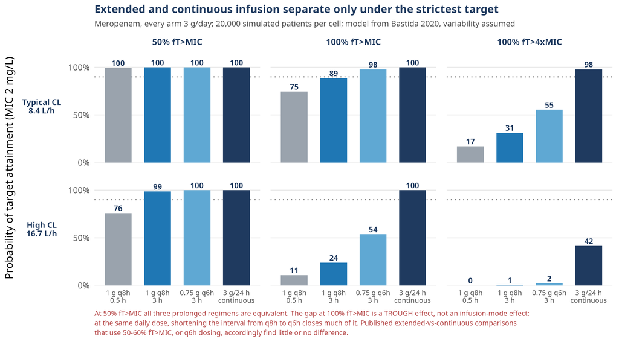

Mechanistic simulation; structural model from (Bastida et al., 2020), variability and strata assumed. Trial evidence randomised prolonged vs bolus: (Abdul-Aziz et al., 2024; Dulhunty et al., 2024; Hong et al., 2026; Monti et al., 2023)

## References

Abdul-Aziz MH, Hammond NE, Brett SJ, Cotta MO, De Waele JJ, Devaux A, Di Tanna GL, Dulhunty JM, others. Prolonged vs Intermittent Infusions of $\beta$-Lactam Antibiotics in Adults With Sepsis or Septic Shock: A Systematic Review and Meta-Analysis. *JAMA* 2024;332:638–648. https://doi.org/10.1001/jama.2024.9803.

Abdulla A, Dijkstra A, Hunfeld NGM, Endeman H, Bahmany S, Ewoldt TMJ, Muller AE, Gelder T van, others. Failure of target attainment of beta-lactam antibiotics in critically ill patients and associated risk factors: a two-center prospective study (EXPAT). *Critical Care* 2020;24:558. https://doi.org/10.1186/s13054-020-03272-z.

Acbo A, Nissim YC, Waterloo M, Ismail O, Gonzalez J. The Impact of Hypoalbuminemia on Antibiotic Therapeutic Outcomes: A Focused Review. *Current Pharmacology Reports* 2025;11:16. https://doi.org/10.1007/s40495-025-00397-z.

Ackerman A, Zook NR, Siegrist JF, Brummitt CF, Cook MM, Dilworth TJ. Comparison of Clinical Outcomes among Intensive Care Unit Patients Receiving One or Two Grams of Ceftriaxone Daily. *Antimicrobial Agents and Chemotherapy* 2020;64:e00066–20. https://doi.org/10.1128/aac.00066-20.

Aldardeer NF, Alshreef MM, Alharbi EA, Aljabri AK, Aljawadi MH, Almangour TA, Alobaili S, Alarifi MI, others. Early Versus Late Antipseudomonal $\beta$-Lactam Antibiotic Dose Adjustment in Critically Ill Sepsis Patients With Acute Kidney Injury: A Prospective Observational Cohort Study. *Open Forum Infectious Diseases* 2024;11:ofae059. https://doi.org/10.1093/ofid/ofae059.

Arensman Hannan K, Draper E, Cole KC, Mc Hugh J, Rivera CG, Abu Saleh O. Impact of hypoalbuminemia on clinical outcomes among patients with obesity treated with ceftriaxone. *Antimicrobial Agents and Chemotherapy* 2024;68:e01663–23. https://doi.org/10.1128/aac.01663-23.

Baalbaki N, Blum S, Akerman M, Johnson D. Ceftriaxone 1 g Versus 2 g Daily for the Treatment of Enterobacterales Bacteremia: A Retrospective Cohort Study. *Journal of Pharmacy Technology* 2022;38:326–334. https://doi.org/10.1177/87551225221121252.

Baptista JP, Neves M, Rodrigues L, others. Accuracy of the estimation of glomerular filtration rate within a population of critically ill patients. *Journal of Nephrology* 2014;27:403–410. https://doi.org/10.1007/s40620-013-0036-x.

Barreto EF, Chang J, Rule AD, Mara KC, Meade LA, Paul J, Jannetto PJ, Athreya AP, others. Population pharmacokinetic model of cefepime for critically ill adults: a comparative assessment of eGFR equations. *Antimicrobial Agents and Chemotherapy* 2023;67:e0081023. https://doi.org/10.1128/aac.00810-23.

Bartoletti M, Giannella M, Lewis RE, Caraceni P, Tedeschi S, Paul M, Schramm C, Bruns T, others. Extended Infusion of $\beta$-Lactams for Bloodstream Infection in Patients With Liver Cirrhosis: An Observational Multicenter Study. *Clinical Infectious Diseases* 2019;69:1731–1739. https://doi.org/10.1093/cid/ciz032.

Bastida C, Hernández-Tejero M, Aziz F, Espinosa C, Sanz M, Brunet M, López E, Fernández J, others. Meropenem population pharmacokinetics in patients with decompensated cirrhosis and severe infections. *Journal of Antimicrobial Chemotherapy* 2020;75:3619–3624. https://doi.org/10.1093/jac/dkaa362.

Benet LZ, Hoener B. Changes in plasma protein binding have little clinical relevance. *Clinical Pharmacology &Amp; Therapeutics* 2002;71:115–121. https://doi.org/10.1067/mcp.2002.121829.

Boschung-Pasquier L, Atkinson A, Kastner LK, Banholzer S, Haschke M, Buetti N, Furrer DI, Hauser C, others. Cefepime neurotoxicity: thresholds and risk factors. A retrospective cohort study. *Clinical Microbiology and Infection* 2020;26:333–339. https://doi.org/10.1016/j.cmi.2019.06.028.

Carlier M, Dumoulin A, Janssen A, Picavet S, Vanthuyne S, Van Eynde R, Vanholder R, Delanghe J, others. Comparison of different equations to assess glomerular filtration in critically ill patients. *Intensive Care Medicine* 2015;41:427–35. https://doi.org/10.1007/s00134-014-3641-9.

Carrié C, Petit L, d’Houdain N, Sauvage N, Cottenceau V, Lafitte M, Foumenteze C, Hisz Q, others. Association between augmented renal clearance, antibiotic exposure and clinical outcome in critically ill septic patients receiving high doses of $\beta$-lactams administered by continuous infusion: a prospective observational study. *International Journal of Antimicrobial Agents* 2018;51:443–449. https://doi.org/10.1016/j.ijantimicag.2017.11.013.

Cheng W, Kiang TKL, Bring P, Ensom MHH. Predictive performance of the Winter-Tozer and derivative equations for estimating free phenytoin concentration. *Canadian Journal of Hospital Pharmacy* 2016;69. https://doi.org/10.4212/cjhp.v69i4.1573.

Chung B, Kamel B, An K, Donaghy H, Roy J, George R, Haghamad A, Doan T-L. P-1299. Clinical Outcomes of Ertapenem in Critically Ill Patients with Bacteremia Caused by ESBL-Producing Organisms: A Comparison of Normal/elevated and Low Albumin Levels. *Open Forum Infectious Diseases* 2026;13:ofaf695.1487. https://doi.org/10.1093/ofid/ofaf695.1487.

Comce MH, Weersink RA, Beuers U, Hest RM van, Lantinga MA. Pharmacokinetics of ceftriaxone, gentamicin, meropenem and vancomycin in liver cirrhosis: a systematic review. *Journal of Antimicrobial Chemotherapy* 2024;79:2750–2761. https://doi.org/10.1093/jac/dkae310.

Crass RL, Rodvold KA, Mueller BA, Pai MP. Renal Dosing of Antibiotics: Are We Jumping the Gun? *Clinical Infectious Diseases* 2019;68:1596–1602. https://doi.org/10.1093/cid/ciy790.

Dulhunty JM, Brett SJ, De Waele JJ, others. Continuous vs intermittent β-lactam antibiotic infusions in critically ill patients with sepsis: The BLING III randomized clinical trial. *JAMA* 2024;332:629. https://doi.org/10.1001/jama.2024.9779.

Ewoldt TMJ, Abdulla A, Rietdijk WJR, Muller AE, Winter BCM de, Hunfeld NGM, Purmer IM, Vliet P van, others. Model-informed precision dosing of beta-lactam antibiotics and ciprofloxacin in critically ill patients: a multicentre randomised clinical trial. *Intensive Care Medicine* 2022;48:1760–1771. https://doi.org/10.1007/s00134-022-06921-9.

Gandia P, Decheiver S, Picard M, Guilhaumou R, Baklouti S, Concordet D. Hypoalbuminemia and Pharmacokinetics: When the Misunderstanding of a Fundamental Concept Leads to Repeated Errors over Decades. *Antibiotics* 2023;12:515. https://doi.org/10.3390/antibiotics12030515.

Gavaghan V, Luu T, Adams J, Santarossa M, Albarillo FS, Rech MA. 602. Clinical Outcomes of Ertapenem in Patients with Hypoalbuminemia. *Open Forum Infectious Diseases* 2022;9:ofac492.654. https://doi.org/10.1093/ofid/ofac492.654.

Gijsen M, Dreesen E, Van Daele R, Annaert P, Debaveye Y, Wauters J, Spriet I. Pharmacokinetic/Pharmacodynamic Target Attainment Based on Measured versus Predicted Unbound Ceftriaxone Concentrations in Critically Ill Patients with Pneumonia: An Observational Cohort Study. *Antibiotics* 2021;10:557. https://doi.org/10.3390/antibiotics10050557.

Grensemann J, Busse D, König C, Roedl K, Jäger W, Jarczak D, Iwersen-Bergmann S, Manthey C, others. Acute-on-chronic liver failure alters meropenem pharmacokinetics in critically ill patients with continuous hemodialysis: an observational study. *Annals of Intensive Care* 2020;10:48. https://doi.org/10.1186/s13613-020-00666-8.

Hagel S, Bach F, Brenner T, Bracht H, Brinkmann A, Annecke T, Hohn A, Weigand M, others. Effect of therapeutic drug monitoring-based dose optimization of piperacillin/tazobactam on sepsis-related organ dysfunction in patients with sepsis: a randomized controlled trial. *Intensive Care Medicine* 2022;48:311–321. https://doi.org/10.1007/s00134-021-06609-6.

Halilovic J, Heintz BH. Antibiotic dosing in cirrhosis. *American Journal of Health-System Pharmacy* 2014;71:1621–1634. https://doi.org/10.2146/ajhp140031.

Hanna PE, Wang Q, Strohbehn IA, Moreno D, Harden D, Ouyang T, Katz-Agranov N, Seethapathy H, others. Medication-Related Adverse Events and Discordancies in Cystatin C-Based vs Serum Creatinine-Based Estimated Glomerular Filtration Rate in Patients With Cancer. *JAMA Network Open* 2023;6:e2321715. https://doi.org/10.1001/jamanetworkopen.2023.21715.

Heffernan AJ, Sime FB, Kumta N, Wallis SC, McWhinney B, Ungerer J, Wong G, Joynt GM, others. Multicenter Population Pharmacokinetic Study of Unbound Ceftriaxone in Critically Ill Patients. *Antimicrobial Agents and Chemotherapy* 2022;66:e0218921. https://doi.org/10.1128/aac.02189-21.

Hefny F, Stuart A, Kung JY, Mahmoud SH. Prevalence and risk factors of augmented renal clearance: A systematic review and meta-analysis. *Pharmaceutics* 2022;14:445. https://doi.org/10.3390/pharmaceutics14020445.

Heine R ter, Kane SP, Huitema ADR, Krasowski MD, Maarseveen EM van. Nonlinear protein binding of phenytoin in clinical practice: development and validation of a mechanistic prediction model. *British Journal of Clinical Pharmacology* 2019;85:2360–2368. https://doi.org/10.1111/bcp.14053.

Hong LT, FakhriRavari A, Ulldemolins M, Roberts JA, Bonomo RA, Scheetz MH, Prolonged‐Infusion Beta‐Lactam Consensus Panel. Focused Update to International Consensus Recommendations for the Use of Prolonged-Infusion Beta-Lactam Antibiotics Among Severely Ill Adult Patients: Endorsed by the American College of Clinical Pharmacy, British Society for Antimicrobial Chemotherapy, Cystic Fibrosis Foundation, European Society of Clinical Microbiology and Infectious Diseases, Infectious Diseases Society of America, Society of Critical Care Medicine, and Society of Infectious Diseases Pharmacists. *Pharmacotherapy: The Journal of Human Pharmacology and Drug Therapy* 2026;46:e70188. https://doi.org/10.1002/phar.70188.

Horstink MMB, Rietdijk WJR, Geel DR, Deetman PE, Endeman H, Koch BCP, Uil CA den. Beta-lactam dose reductions in critically ill patients with acute kidney injury: a scoping review. *Critical Care* 2025;30:8. https://doi.org/10.1186/s13054-025-05736-6.

Hoste EAJ, Bagshaw SM, Bellomo R, others. Epidemiology of acute kidney injury in critically ill patients: The multinational AKI-EPI study. *Intensive Care Medicine* 2015;41:1411–1423. https://doi.org/10.1007/s00134-015-3934-7.

Imani S, Buscher H, Marriott D, Gentili S, Sandaradura I. Too much of a good thing: a retrospective study of $\beta$-lactam concentration-toxicity relationships. *Journal of Antimicrobial Chemotherapy* 2017;72:2891–2897. https://doi.org/10.1093/jac/dkx209.

Kiang TKL, Ensom MHH. A comprehensive review on the predictive performance of the Sheiner-Tozer and derivative equations for the correction of phenytoin concentrations. *Annals of Pharmacotherapy* 2016;50:311–325. https://doi.org/10.1177/1060028016628166.

Kullar R, Wagenlehner FM, Popejoy MW, Long J, Yu B, Goldstein EJC. Does moderate renal impairment affect clinical outcomes in complicated intra-abdominal and complicated urinary tract infections? Analysis of two randomized controlled trials with ceftolozane/tazobactam. *Journal of Antimicrobial Chemotherapy* 2017;72:900–905. https://doi.org/10.1093/jac/dkw486.

Kurland S, Furebring M, Löwdin E, Eliasson E, Nielsen EI, Sjölin J. Pharmacokinetics of Caspofungin in Critically Ill Patients in Relation to Liver Dysfunction: Differential Impact of Plasma Albumin and Bilirubin Levels. *Antimicrobial Agents and Chemotherapy* 2019;63. https://doi.org/10.1128/AAC.02466-18.

Liebchen U, Kratzer A, Wicha SG, Kees F, Kloft C, Kees MG. Unbound fraction of ertapenem in intensive care unit patients. *Journal of Antimicrobial Chemotherapy* 2014;69:3108–11. https://doi.org/10.1093/jac/dku226.

Martial LC, Brüggemann RJM, Schouten JA, Leeuwen HJ van, Zanten AR van, Lange DW de, Muilwijk EW, Verweij PE, others. Dose Reduction of Caspofungin in Intensive Care Unit Patients with Child Pugh B Will Result in Suboptimal Exposure. *Clinical Pharmacokinetics* 2016;55:723–33. https://doi.org/10.1007/s40262-015-0347-2.

Monti G, Bradic N, Marzaroli M, others. Continuous vs intermittent meropenem administration in critically ill patients with sepsis: The MERCY randomized clinical trial. *JAMA* 2023;330:141. https://doi.org/10.1001/jama.2023.10598.

Moser S, Rehm S, Guertler N, Hinic V, Dräger S, Bassetti S, Rentsch KM, Sendi P, others. Probability of pharmacological target attainment with flucloxacillin in Staphylococcus aureus bloodstream infection: a prospective cohort study of unbound plasma and individual MICs. *Journal of Antimicrobial Chemotherapy* 2021;76:1845–1854. https://doi.org/10.1093/jac/dkab089.

Nadim MK, Kellum JA, Forni L, Francoz C, Asrani SK, Ostermann M, Allegretti AS, Neyra JA, others. Acute kidney injury in patients with cirrhosis: Acute Disease Quality Initiative (ADQI) and International Club of Ascites (ICA) joint multidisciplinary consensus meeting. *Journal of Hepatology* 2024;81:163–183. https://doi.org/10.1016/j.jhep.2024.03.031.

Pai Mangalore R, Ashok A, Lee SJ, Romero L, Peel TN, Udy AA, Peleg AY. Beta-Lactam Antibiotic Therapeutic Drug Monitoring in Critically Ill Patients: A Systematic Review and Meta-Analysis. *Clinical Infectious Diseases* 2022;75:1848–1860. https://doi.org/10.1093/cid/ciac506.

Parikh L, MacLaren R. The predictive performances of equations used to estimate unbound phenytoin concentrations in a medical ICU population and the impact of exogenous albumin administration. *Journal of Critical Care* 2018;44:95–100. https://doi.org/10.1016/j.jcrc.2017.10.028.

Payne LE, Gagnon DJ, Riker RR, Seder DB, Glisic EK, Morris JG, Fraser GL. Cefepime-induced neurotoxicity: a systematic review. *Critical Care* 2017;21:276. https://doi.org/10.1186/s13054-017-1856-1.

Prescott HC, Antonelli M, Alhazzani W, Møller MH, Alshamsi F, Azevedo LCP, Belley-Cote E, De Waele J, others. Surviving Sepsis Campaign: International Guidelines for Management of Sepsis and Septic Shock 2026. *Critical Care Medicine* 2026;54:725–812. https://doi.org/10.1097/CCM.0000000000007075.

Qian ET, Casey JD, Wright A, Wang L, Shotwell MS, Siemann JK, Dear ML, Stollings JL, others. Cefepime vs Piperacillin-Tazobactam in Adults Hospitalized With Acute Infection: The ACORN Randomized Clinical Trial. *JAMA* 2023;330:1557–1567. https://doi.org/10.1001/jama.2023.20583.

Roberts JA, Joynt GM, Lee A, Choi G, Bellomo R, Kanji S, Mudaliar MY, Peake SL, others. The Effect of Renal Replacement Therapy and Antibiotic Dose on Antibiotic Concentrations in Critically Ill Patients: Data From the Multinational Sampling Antibiotics in Renal Replacement Therapy Study. *Clinical Infectious Diseases* 2021;72:1369–1378. https://doi.org/10.1093/cid/ciaa224.

Roberts JA, Ulldemolins M, Liu X, Baptista JP, Bilgrami I, Boidin C, Brinkmann A, Castro P, others. Meropenem and piperacillin/tazobactam optimised dosing regimens for critically ill patients receiving renal replacement therapy. *Intensive Care Medicine* 2025;51:1628–1640. https://doi.org/10.1007/s00134-025-08067-w.

Roggeveen LF, Guo T, Fleuren LM, Driessen R, Thoral P, Hest RM van, Mathot RAA, Swart EL, others. Right dose, right now: bedside, real-time, data-driven, and personalised antibiotic dosing in critically ill patients with sepsis or septic shock-a two-centre randomised clinical trial. *Critical Care* 2022;26:265. https://doi.org/10.1186/s13054-022-04098-7.

Schleibinger M, Steinbach CL, Töpper C, Kratzer A, Liebchen U, Kees F, Salzberger B, Kees MG. Protein binding characteristics and pharmacokinetics of ceftriaxone in intensive care unit patients. *British Journal of Clinical Pharmacology* 2015;80:525–33. https://doi.org/10.1111/bcp.12636.

Shah S, Clarke LG, Balasubramani GK, Peng L, Smith BJ, Shields RK. Impact of hypoalbuminemia on patients receiving ertapenem combination therapy for methicillin-susceptible <i>Staphylococcus aureus</i> bacteraemia. *Journal of Antimicrobial Chemotherapy* 2025;80:1823–1827. https://doi.org/10.1093/jac/dkaf134.

Shah S, Peng L, Clarke LG, Balasubramani GK, Smith BJ, Shields RK. Evaluating hypoalbuminaemia thresholds associated with delayed blood sterilization among patients receiving cefazolin or antistaphylococcal penicillins for MSSA bacteraemia. *Journal of Antimicrobial Chemotherapy* 2026;81. https://doi.org/10.1093/jac/dkaf498.

Singapura P, Ma T-W, Sarmast N, Gonzalez SA, Durand F, Maiwall R, Nadim MK, Fullinwider J, others. Estimating Glomerular Filtration Rate in Cirrhosis Using Creatinine-Based and Cystatin C-Based Equations: Systematic Review and Meta-Analysis. *Liver Transplantation* 2021;27:1538–1552. https://doi.org/10.1002/lt.26216.

Steere EL, Eubank TA, Cooper MH, Greenlee SB, Drake TC. Impact of Hypoalbuminemia on Ceftriaxone Treatment Failure in Patients With Enterobacterales Bacteremia: A Propensity-Matched, Retrospective Cohort Study. *Open Forum Infectious Diseases* 2023;10. https://doi.org/10.1093/ofid/ofad102.

T’jollyn H, Vermeulen A, Van Bocxlaer J, Colin P. A Physiologically Based Pharmacokinetic Perspective on the Clinical Utility of Albumin-Based Dose Adjustments in Critically Ill Patients. *Clinical Pharmacokinetics* 2018;57:59–69. https://doi.org/10.1007/s40262-017-0549-x.

Tamma PD, Heil EL, Justo JA, Mathers AJ, Satlin MJ, Bonomo RA. Infectious Diseases Society of America 2024 Guidance on the Treatment of Antimicrobial-Resistant Gram-Negative Infections. *Clinical Infectious Diseases* 2024. https://doi.org/10.1093/cid/ciae403.

Toutain P-L, Gandia P, Pelligand L, Ferran AA, Lees P, Bousquet-Mélou A, Concordet D. Biased computation of probability of target attainment for antimicrobial drugs. *CPT: Pharmacometrics & Systems Pharmacology* 2023;12:681–689. https://doi.org/10.1002/psp4.12929.

Udy AA, Baptista JP, Lim NL, Joynt GM, Jarrett P, Wockner L, Boots RJ, Lipman J. Augmented renal clearance in the ICU: Results of a multicenter observational study of renal function in critically ill patients with normal plasma creatinine concentrations. *Critical Care Medicine* 2014;42:520–527. https://doi.org/10.1097/CCM.0000000000000029.

Udy AA, Varghese JM, Altukroni M, Briscoe S, McWhinney BC, Ungerer JP, Lipman J, Roberts JA. Subtherapeutic initial $\beta$-lactam concentrations in select critically ill patients: association between augmented renal clearance and low trough drug concentrations. *Chest* 2012;142:30–39. https://doi.org/10.1378/chest.11-1671.

Ulldemolins M, Lipman J, Liu X, Abdul-Aziz M-H, Baptista JP, Bilgrami I, Bitker L, Boidin C, others. Vancomycin optimised dosing regimens for critically ill patients receiving renal replacement therapy. *Critical Care* 2026;30. https://doi.org/10.1186/s13054-026-06226-z.

US Food and Drug Administration. ZERBAXA (ceftolozane and tazobactam) prescribing information. Section 5.1, Decreased efficacy in patients with baseline creatinine clearance of 30 to 50 mL/min; Table 6. 2022.

US Food and Drug Administration. AVYCAZ (ceftazidime and avibactam) prescribing information. Section 5.1, Decreased clinical response in adult cIAI patients with baseline creatinine clearance of 30 to less than or equal to 50 mL/min; Table 10. 2025.

VanDorf S, Shah P, Yost CN. Ertapenem Versus Meropenem for the Treatment of Extended Spectrum Beta-Lactamase-Producing Enterobacterales Bacteremia in Critically Ill Patients. *Annals of Pharmacotherapy* 2024;58:690–697. https://doi.org/10.1177/10600280231205219.

Verbeeck RK. Pharmacokinetics and dosage adjustment in patients with hepatic dysfunction. *European Journal of Clinical Pharmacology* 2008;64:1147–1161. https://doi.org/10.1007/s00228-008-0553-z.

Wallenburg E, Ter Heine R, Lange DW de, Leeuwen H van, Schouten JA, Ten Oever J, Kolwijck E, Burger DM, others. High unbound flucloxacillin fraction in critically ill patients. *Journal of Antimicrobial Chemotherapy* 2021;76:3220–3228. https://doi.org/10.1093/jac/dkab314.

Wong G, Briscoe S, Adnan S, McWhinney B, Ungerer J, Lipman J, Roberts JA. Protein binding of $\beta$-lactam antibiotics in critically ill patients: can we successfully predict unbound concentrations? *Antimicrobial Agents and Chemotherapy* 2013;57:6165–70. https://doi.org/10.1128/AAC.00951-13.

Wong G, Briscoe S, McWhinney B, Ally M, Ungerer J, Lipman J, Roberts JA. Therapeutic drug monitoring of $\beta$-lactam antibiotics in the critically ill: direct measurement of unbound drug concentrations to achieve appropriate drug exposures. *Journal of Antimicrobial Chemotherapy* 2018;73:3087–3094. https://doi.org/10.1093/jac/dky314.

Zusman O, Farbman L, Tredler Z, Daitch V, Lador A, Leibovici L, Paul M. Association between hypoalbuminemia and mortality among subjects treated with ertapenem versus other carbapenems: prospective cohort study. *Clinical Microbiology and Infection* 2015;21:54–58. https://doi.org/10.1016/j.cmi.2014.08.003.